# BD Datasets - Combine and Eval

Skye Wills

May 5, 2017

# Combine BD datasets do basic evaluation

Set up to run once; haven’t cleaned it up to check if files exsit first

## Setup

load necessary library and set path to working directlry This file is available in the online folder - https://www.cloudvault.usda.gov/index.php/s/nbBSsnNCFguRyht. This folder can be browsed for more information.

**This sets the loction for file dowload - edit BD_data or setwd()**

```r
#A large amount of data is read in, clear and check first
rm(list = ls() ) #clear environment
memory.limit(size=NA)
```

```
## [1] 8142
```

```r
#loda necessary libraries
#library(randomForest) #Bagging random forest models
library(tidyverse) #adds other packages - like dplyr for piping and tidy editing
#library(RCurl) #allows you to set a web connection
library(RCurl) #to download web data
```

```r
#point to folder I have synced with this cloudvault folder
#https://www.cloudvault.usda.gov/index.php/s/nbBSsnNCFguRyht


BD_data <- "C:/Users/skye.wills/ownCloud/BD_eval/"
#BD_data("C:/Users/skyew/ownCloud/BD_eval")
```

## Bulk Density data

### Bring in datasets used to model bulk density.

**NCSS** - National Cooperative Soil Survey Characterization dataset. Prepped from the public dataset (Access) from August 2015 http://ncsslabdatamart.sc.egov.usda.gov/following the methods in Prep SOC and BD data.doc. https://www.cloudvault.usda.gov/index.php/s/7tieyXcVLaAjlW8

**RaCA** - Rapid Carbon Assessment sample dataset. Full description online. https://www.nrcs.usda.gov/wps/portal/nrcs/detail/soils/survey/?cid=nrcs142p2_054164 All data shared.https://www.nrcs.usda.gov/Internet/FSE_MANUSCRIPTS/alabama/RaCA_Download/RaCA_Download.zip

**NWCA** - National Wetland Condition Assessment (2016) see NWCA.pred.meta.xlsx for more information - https://www.cloudvault.usda.gov/index.php/s/Pd6qlwRFIib3bCN

**ISCN** - International Soil Carbon Network (2016) - filled missing Bulk Density for Luke Nave. See BDfill_wMeta.xlsx for more information https://www.cloudvault.usda.gov/index.php/s/wsVysIYqZa3YIbu

**this code chunk downloads data into the folder you set to BD_data - uncomment to run**

```r
#
# #download file to the working directory - creates new folder data
# #will save raw data into this folder
# ifelse(!dir.exists(paste0(BD_data,'/data')), dir.create(paste0(BD_data,'/data')), FALSE)  #True means the file was created, FALSE means it alread exsists
#
# ncss.url <- 'https://www.cloudvault.usda.gov/index.php/s/7tieyXcVLaAjlW8/download'
# #if file does not exsist, download
# ifelse(!file.exists('data/ncss.w.bd.csv'),download.file(ncss.url, destfile = paste0(BD_data,'/data/ncss.w.bd.csv')), "File already downloaded")
#
#
# raca.url <- 'https://www.cloudvault.usda.gov/index.php/s/OuKFMmVDG3B0eYG/download'
# ifelse(!file.exists('data/RaCA_samples.csv'), download.file(raca.url, destfile = paste0(BD_data,'/data/RaCA_samples.csv') )
#        , "File already downloaded")
#
# nwca.url <- 'https://www.cloudvault.usda.gov/index.php/s/z0no9LVguqWFX1t/download'
# ifelse(!file.exists('data/nwca.SOCsamples_5-10.csv'), download.file(nwca.url, destfile = paste0(BD_data,'/data/nwca.SOCsamples_5-10.csv')), "File already downloaded")
#
# iscn.url <- 'https://www.cloudvault.usda.gov/index.php/s/QXNDDCwVSPd3Snw/download'
# ifelse(!file.exists('data/ISCN_BDfill_pred_wMEtA.csv'),download.file(iscn.url, destfile = paste0(BD_data,'/data/ISCN_BDfill_pred_wMEtA.csv')), "File already downloaded")
```

## Read Data into R and Prep

### Combine dataset into one

- check field names
- Select rows that have BD measurement
- choose same set for each dataset
- Add any missing fields
- rename to same field names
- Add SET to denote dataset
- LU - to match RaCA W- wetland, C- cropland, P- pastureland, F - Forestland, X- CRP, U added for unknown

*Texture labels need to be assessed in ensure the same abbreviations are being used* *wpg for ISCN needs to be converted to volumetric fragment content*

```r
ncss <- read.csv(paste0(BD_data, 'data/ncss.w.bd.csv'))
names(ncss)
```

```
##  [1] "sample_id"     "upedonid"      "mod_pedon_key" "pedlabsampnum"
##  [5] "Order"         "top"           "bottom"        "Model_desg"
##  [9] "M"             "Hzn_avg"       "Thick"         "Texture"
## [13] "SAND"          "SILT"          "CLAY"          "SOC"
## [17] "BD"            "samp"          "above"         "below"
## [21] "ped"           "Actual"        "labsampnum"    "hzn_desgn"
## [25] "c_tot"         "oc"            "carb"          "CF"
## [29] "tex_descrp"    "tex_psda"      "Bulk.Density"  "BD.source"
```

```r
n <- ncss[!is.na(ncss$BD), c("sample_id", "top", "bottom", "Model_desg", "M", "tex_psda", "CLAY", "SOC", "CF", "BD")]
names(n) <- c("samp_id", "Top", "Bottom", "Model_desg", "M", "Texture", "Clay", "SOC", "CourseFrag", "BD" )
n$LU <- "U" #U for unknown landuse
n$SET <- "NCSS"

raca <- read.csv(paste0(BD_data,'data/RaCA_samples.csv'))
names(raca)
```

```
##  [1] "samp"                "sample.id"           "TOP"
##  [4] "BOT"                 "hzn_desgn"           "rcasiteid"
##  [7] "pedon_no"            "MO"                  "MOGr"
## [10] "hor_top"             "hor_bot"             "fragvolc"
## [13] "Bulkdensity"         "SOC_pred1"           "BD1"
## [16] "upedonid"            "upedon"              "LU"
## [19] "MOGrLU"              "hzname"              "model_desg1"
## [22] "texture"             "BDmeasured"          "BDmethod"
## [25] "Lab.Sample.No"       "lab_proj_name"       "submit_proj_name"
## [28] "user_site_id"        "smp_id"              "lay_field_label1"
## [31] "lay_field_label2"    "lay_field_label3"    "lay_depth_to_top"
## [34] "lay_depth_to_bottom" "horizon_designation" "natural_key"
## [37] "lay_id"              "adod"                "c_tot_ncs"
## [40] "n_tot_ncs"           "s_tot_ncs"           "caco3"
## [43] "efferv_1nhcl"        "M"                   "Model_desg"
## [46] "Texture"             "Measure_BD"          "Model_BD"
```

```r
raca$CALC_SOC <- ifelse(!is.na(raca$caco3),
                        ifelse(raca$caco3>0,raca$c_tot_ncs-(raca$caco3*0.12),raca$c_tot_ncs), raca$c_tot_ncs)
raca$SOC <- ifelse(raca$CALC_SOC<0, 0, raca$CALC_SOC)
r <- raca[!is.na(raca$Measure_BD), c("samp", "TOP", "BOT", "Model_desg", "M", "texture", "fragvolc", "SOC", "Measure_BD", "LU")]
names(r) <- c("samp_id", "Top", "Bottom", "Model_desg", "M", "Texture",  "CourseFrag", "SOC", "BD", "LU" )
r$SET <- "RaCA"
r$Clay <- NA

nwca <- read.csv(paste0(BD_data,'/data/nwca.SOCsamples_5-10.csv'))
names(nwca)
```

```
##  [1] "samp"           "Pedon"          "Order"          "top"
##  [5] "bottom"         "Model_desg"     "M"              "Hzn_avg"
##  [9] "Thick"          "Texture"        "SAND"           "SILT"
## [13] "CLAY"           "SOC"            "BD"             "Model"
## [17] "Measured"       "SITE_PIT_VISIT" "UID"            "DATE_COL"
## [21] "SITE_ID"        "SITE_USE"       "VISIT_NO"       "PIT"
## [25] "REP_PIT"        "LAYER"          "HORIZON"        "TOP"
## [29] "BOTTOM"         "SANDY"          "LOAMY"          "MK_MIN"
## [33] "ORGANIC"        "ROCK_FRAGMENTS" "TEXTURE_CLASS"  "Bulk.Density"
## [37] "SOCd"           "SOC_5"          "SOC_30"         "SOC_100"
## [41] "SOCden"         "SOCstock5"      "SOCstock30"     "SOCstock100"
```

```r
w <- nwca[!is.na(nwca$BD), c( "samp", "top", "bottom", "Model_desg" , "M", "TEXTURE_CLASS", "CLAY", "ROCK_FRAGMENTS", "SOC", "BD")]
names(w) <- c("samp_id", "Top", "Bottom", "Model_desg", "M", "Texture", "Clay", "CourseFrag", "SOC", "BD")
w$LU <- "W"
w$SET <- "NWCA"

iscn <- read.csv(paste0(BD_data,'data/ISCN_BDfill_pred_wMEtA.csv'))
names(iscn)
```

```
##  [1] "hzn_desgn"        "dataset_name"     "site_name"
##  [4] "profile_name"     "layer_name"       "layer_top"
##  [7] "layer_bot"        "c_method"         "bd_method"
## [10] "BD"               "bd_tot"           "bd_whole"
## [13] "bd_other"         "bdNRCS_prep_code" "SAND"
## [16] "SILT"             "CLAY"             "wpg2_method"
## [19] "wpg2"             "soc"              "soc_sigma"
## [22] "soc_method"       "SOC"              "oc"
## [25] "cNRCS_prep_code"  "typ"              "ID"
## [28] "model_desg"       "md2"              "M"
## [31] "m"                "Model_desg"       "Thick"
## [34] "Hzn_avg"          "hzn_desgn.1"      "dataset_name.1"
## [37] "site_name.1"      "profile_name.1"   "BDfill.ALT.pred"
## [40] "BDfill.lab.pred"  "X"                "resid_lab"
```

```r
#need to convert weight coarse frag to volume
i <- iscn[!is.na(iscn$BD), c("layer_name", "layer_top", "layer_bot", "model_desg" , "M", "CLAY", "wpg2", "SOC", "BD") ]
names(i) <- c("samp_id", "Top", "Bottom", "Model_desg", "M", "Clay", "CourseFrag", "SOC", "BD")
i$Clay <- as.numeric(i$Clay)
i$Texture <- "U"
i$LU <- "U"
i$SET <- "ISCN"


#combine dataset into one - missing values are filled with NA
combo <- rbind(n,r,w,i)
```

## Compare Datasets

Use dplyr (with piping) to format and ggplot to create graphs

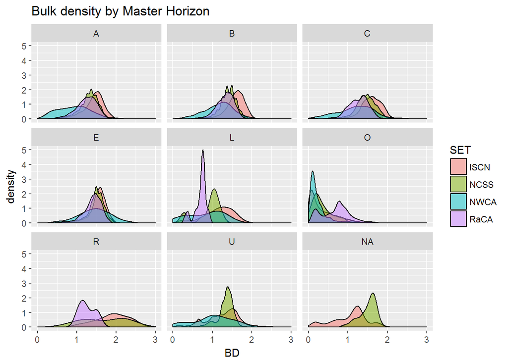

```r
D <- combo %>%
  ggplot(aes(BD)) + geom_density(aes(fill = SET), alpha=.5) + scale_x_continuous(limits = c(0,3)) +
  facet_wrap(~M) + ggtitle('Bulk density by Master Horizon')
D
```

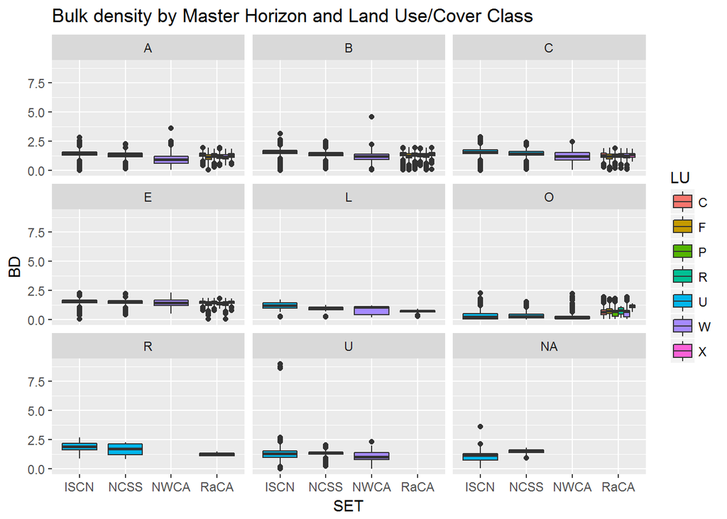

```r
B <- combo %>%
  filter(!is.na(BD)) %>%
  ggplot(aes(y = BD, x=SET)) + geom_boxplot(aes(fill=LU)) +
  facet_wrap(~M) + ggtitle('Bulk density by Master Horizon and Land Use/Cover Class')
B
```

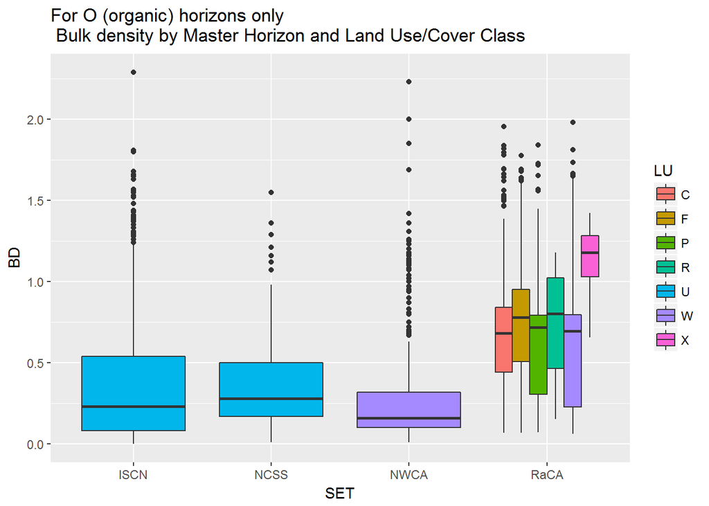

```r
O <- combo %>%
  filter(!is.na(BD) & M == "O") %>%
  ggplot(aes(y = BD, x=SET)) + geom_boxplot(aes(fill=LU)) +
  ggtitle('For O (organic) horizons only \n Bulk density by Master Horizon and Land Use/Cover Class')
O
```

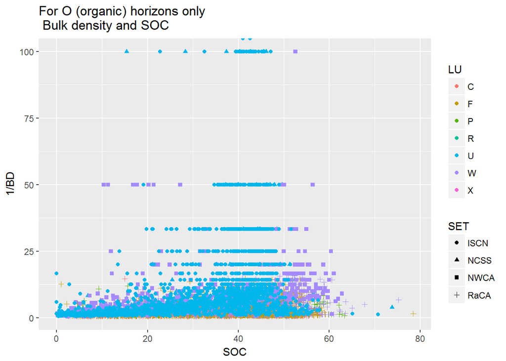

```r
S <- combo %>%
  filter(!is.na(BD) & M == "O") %>%
  ggplot(aes(y = 1/BD, x=SOC)) + geom_point(aes(color=LU, shape = SET)) +
  ggtitle('For O (organic) horizons only \n Bulk density and SOC')
S
```

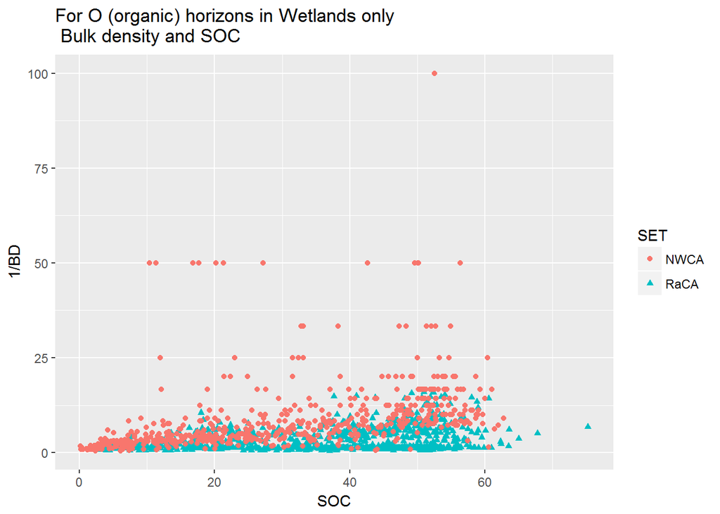

```r
Sw <- combo %>%
  filter(!is.na(BD) & M == "O" & LU == "W") %>%
  ggplot(aes(y = 1/BD, x=SOC)) + geom_point(aes(color=SET, shape = SET)) +
  ggtitle('For O (organic) horizons in Wetlands only \n Bulk density and SOC')
Sw
```